# Topic 23

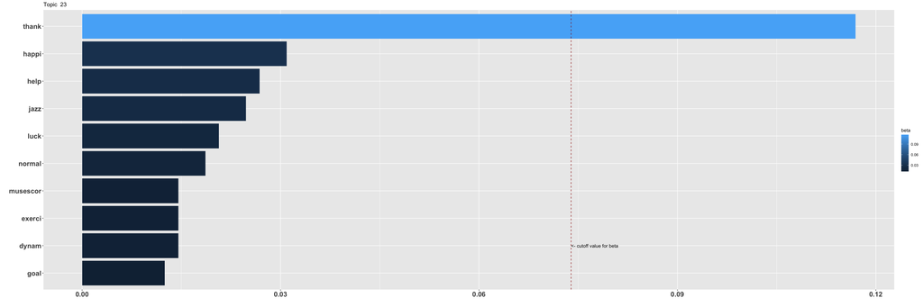

On interpreting beta: the term has a beta probability of being generated from the particular topic.

Values below are gamma : An estimated proportion of words from that document that are generated from that topic.

**Text Record Number: 1222** gamma: 10 % likelihood of this document (based on its words) in this topic

**I gave up my piano teacher a few months ago and I am happy with that: I am following Mark Davis’ Jazz Piano Method, Mark Levine’s The Jazz Piano Book and LearnJazzStandards.com courses and I am now free to study at my own pace (30m per day), but… I miss the lesson. Well, actually not the lesson itself, but its role in my studying. It was a moment for checking how I was progressing and setting goals for the next week.

Any self-thought here who can share his/her experience and how to set weekly goals or something like that?**

**Text Record Number: 1124** gamma: 10 % likelihood of this document (based on its words) in this topic

**Thanks for the reply! My main goal when I started was to learn River Flows in You. Would you recommend the P-71 or is there a better one I should look into?**

**Text Record Number: 1403** gamma: 10 % likelihood of this document (based on its words) in this topic

**Hello Piano Learning community!

I’ve been following this sub for a while now and found some interesting input here, thank you all for sharing your problems and experiences. I started to learn piano 1,5 years ago with a really good teacher. She usually explains quite well what I am lacking and with her insight and reflection I can improve my play step by step.

But lately, one of her critics is giving me a real hard time, and I am not sure how to work on that properly.

She says, I have to listen to myself more actively while playing and it is true: for parts, which cover a wider range or a (for me) more complex rhythm, my brain is focused on the mechanics of my finger and my arms, but how can I improve or change this behaviour? I have tried to suppress over thinking while playing, but I just can’t seem to find the switch, to suppress thoughts while playing. I also have a lot of trust issues to hit the wrong keys, if I don’t eye my fingers constantly.

Has someone experienced this too and how do you guys overcome overthinking while playing? Is there any exercise I can do? Or any mantra, with which I can trick myself into trusting my fingers?

Thanks for your advice in advance and happy practicing :)**

**Text Record Number: 1195** gamma: 10 % likelihood of this document (based on its words) in this topic

**Thank you💖🙏🏻you are just so awesome 🤗you’re so kind doing that for me! It catched some things I wanted to know. I’m happy I knew the theory with chords and etc to understand you👍🏻and you showed me some patterns he did. I already knew the basics how patterns are build with chord tones but not more advanced ones in that style. I will look up and ask you for specific patterns in some minutes . I understand that you try to translate the other instruments drums etc into rhythmic patterns but perhaps you have some tips how to decide what pattern? I’m so grateful you took your time 🙏🏻 of course I subbed your channel its the least I can do 🤗**

**Text Record Number: 1196** gamma: 10 % likelihood of this document (based on its words) in this topic

**Alright, [I threw together quick video](https://youtu.be/hsR2w5SRqbE) explaining this with a few examples that I could glean from what he was playing based on a quick watch.

If you want me to try to pick apart a very specific pattern from the video (or any other one) I’d be happy to see if I could do that too.

The TL;DW is that you just have to be able to spell your chords and then pick notes from them, but that’s obviously a bit simplified.

Oh… and I guess /u/Abhigyan9652 might wanna be tagged in on this answer.**

**Text Record Number: 679** gamma: 10 % likelihood of this document (based on its words) in this topic

**Yes this is a struggle for me too.

>PS, pretty sure this piece won’t stay in your list for long still, given the amount of time you dedicate to practice (fellow tuneupgrade user here). I’m honestly impressed, I would never be able to play that much every day. :) hope to hear something from you soon.

Lol I’m probably just counteracting my lack of talent. Right now I’m working on Clementi sonatina op. 36 no. 2 when I’m done I’ll post the first movement to get some feedback.**

**Text Record Number: 922** gamma: 10 % likelihood of this document (based on its words) in this topic

**I’m just learning myself and I am not musical at all. You are going to do so well with your background!

I downloaded an app called “Clefs” to help me read notes. There were a lot of apps available, but I tried a few others out, didn’t like them, and deleted them. Clefs I have kept! It has tests and quizzes. I’m maybe getting better, but I also just get overwhelmed so I have to repeat lessons a lot. :(

Lastly, I want to petition for all former drummers who learn piano to be called finger drummers. This is somehow important to me.**